# Module 2, Lesson 2b: SLR with dichotomized predictors

```r
library(healthds)
library(tidyverse)
```

In this independent guide, we will learn how to regress an outcome on a dichotomous variable and how to interpret the results. We will also start to make a connection to the t-test, which Dr. Mukherjee will make clear in her upcoming lecture.

To begin, we will create a dichotomous version of age from the `BPUrban300` data using a new function from the `tidyverse` called `case_when`:

```r
BPUrban300 %>%
  mutate(age_gt66 = case_when(age > 66 ~ "yes",
                              age <= 66 ~ "no")) %>%
  select(age, age_gt66) %>%
  head()
```

```
##   age age_gt66
## 1  60       no
## 2  57       no
## 3  54       no
## 4  75      yes
## 5  71      yes
## 6  33       no
```

Let’s go over each line above one at a time. First we call `mutate` and create a new variable `age_gt66` (“age greater than 66”). It is defined using `case_when`: when the `age` variable (which already exists in `BPUrban300`) exceeds 66, then we instruct that `age_gt66` should take on the value `"yes"` (a character); when the `age` variable is less than or equal to 66, then we instruct that `age_gt66` should take on the value `"no"`. Note that we use the tilde (`~`, which we’ve also seen used in the `formula` argument of `lm`) to separate the condition (on its left) from the resulting value if the condition is true (on its right). For each observation in your data `case_when` will evaluate each condition, one at a time, until it finds one that is true, and that observation will be assigned the corresponding value. On the next line, we are selecting only `age` and the newly created `age_gt66` variables, simply to assess whether we have constructed the variable correctly. Finally, we use the `head` function, introduced in the first Independent Guide of this Module, to inspect just the first 6 rows of the result. Comparing `age` to `age_gt66`, we see that this variable seems to have been appropriately constructed: in the first row, the person’s `age` was 60 and `age_gt66` was ‘no’; in the fourth row, the person’s `age` was 75 and `age_gt66` ‘yes’.

Now we are ready to fit a linear regression against dichotomous age. We copy and paste the code from above that creates this variable and then pipe it into a call to `lm`, this time putting `age_gt66` on the right-hand side of the formula:

```r
BPUrban300 %>%
  mutate(age_gt66 = case_when(age > 66 ~ "yes",
                              age <= 66 ~ "no")) %>%
  lm(formula = systolic ~ age_gt66) %>%
  summary()
```

```
##
## Call:
## lm(formula = systolic ~ age_gt66, data = .)
##
## Residuals:
##     Min      1Q  Median      3Q     Max
## -61.093 -13.762   1.907  14.990  48.907
##
## Coefficients:
##             Estimate Std. Error t value Pr(>|t|)
## (Intercept)  118.093      1.436   82.24  < 2e-16 ***
## age_gt66yes   16.669      3.133    5.32 2.05e-07 ***
## ---
## Signif. codes:  0 '***' 0.001 '**' 0.01 '*' 0.05 '.' 0.1 ' ' 1
##
## Residual standard error: 22.11 on 298 degrees of freedom
## Multiple R-squared:  0.08673,    Adjusted R-squared:  0.08366
## F-statistic:  28.3 on 1 and 298 DF,  p-value: 2.045e-07
```

Note that the parameter estimates take on different values when compared to our previous fitted linear regression of systolic blood pressure against (continuously valued) age. Not only are the values different but also the *interpretations*. In the fitted model, the estimated intercept is now 118.1 and the estimated regression coefficient for `age_gt66` is 16.7. What do these mean?

When we have a binary predictor like `age_gt66` in our model, we must first identify the so-called ‘reference category’ for that predictor. Whenever you provide a variable with named categories as opposed to numbers, R automatically translates these into 0/1 variables. In this case, one value of `age_gt66` has been assigned to 0 (the reference category) and the other value has been assigned to 1. We can tell which value has been assigned to 1 by looking at the name of the second row of the Coefficients table: `age_gt66yes`. This means that the ‘yes’ values have been assigned to 1 and therefore that the ‘no’ values has been assigned to 0.

Knowing this, we can interpret 118.1 to be the estimated systolic blood pressure for any person who is 66 years old or younger, and 16.7 is the estimated change in systolic blood pressure between someone who is 66 years old or younger versus someone who is older than 66. Moreover, we can know that 134.8 (or 118.1 + 16.7) is the estimated systolic blood pressure for someone who is older than 66 years.

Take note of the assumption that we have imposed on this model: everyone who is 66 years old or younger in our data has a common estimated systolic blood pressure, and similarly for everyone who is older than 66 years. This is not necessarily a better or worse assumption than our previous one, which imposed a different belief that systolic blood pressure changes with age in a constant fashion.

### Visualizing SLR with a binary predictor

Now let’s view the fitted regression line under this dichotomous age. To do so, we use a new geometric object called `geom_segment`, which allows you to plot lines that have a start and end on your plot:

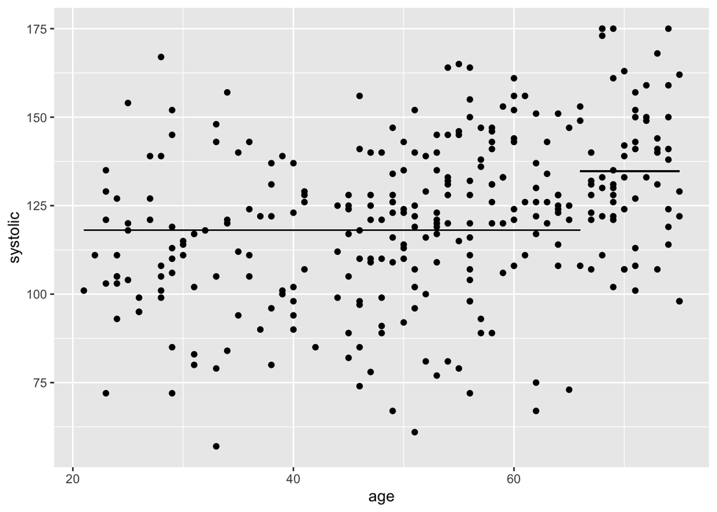

```r
ggplot(BPUrban300) +
  geom_point(aes(age, systolic)) +
  geom_segment(aes(x = 21, xend = 66, y = 118.09, yend = 118.09)) +
  geom_segment(aes(x = 66, xend = 75, y = 118.09 + 16.669, yend = 118.09 + 16.669))
```

We must provide the starting and ending values of the x-coordinates, `x` and `xend`, as well as the starting and ending values of the y-coordinates, `y`, and `yend`. What’s plotted is a line segment connecting (`x`,`y`) to (`xend`, `yend`). The first call to `geom_segment` plots the fitted regression line for those who are 66 years old or younger, and the second plots the fitted regression line for those who are older than 66 years.

One small aside: in his Guided Practice, Dr. Boonstra put the `x`, `xend`, `y`, and `yend` arguments inside the `aes` function. In doing so, some of you may have noticed that he did not follow the grammar of graphics that we learned in Course 1: instead of *mapping* these aesthetics to variables in the data, we should have been *setting* these aesthetics at particular values. Therefore, he should not have put these inside the `aes` function, and the more correct version of this code looks like this:

```r
ggplot(BPUrban300) +
  geom_point(aes(age, systolic)) +
  geom_segment(x = 21, xend = 66, y = 118.09, yend = 118.09) +
  geom_segment(x = 66, xend = 75, y = 118.09 + 16.669, yend = 118.09 + 16.669)
```

In this case, the resulting plot looks identical, but that will not necessarily always be the case.

### Connecting back to the t-test

As you will see in the next video lecture from Dr. Mukherjee, a simple linear regression with one binary predictor is in fact very similar to conducting a t-test, in this case, comparing the average systolic blood pressure in the group of persons older than 66 years against the average systolic blood pressure in the group of persons 66 years old or younger.